# Education Analysis by County

Kyle Kirk’s Data Science Portfolio

This builds upon the first part, from `insights.Rmd`

Instead, I will focus on unemployment and education. I want to see if there is a correlation between unemployment and rates of education on a county level. We’ll start with reading in an excel spreadsheet.

```r
Education <- read_excel("Education.xls")
```

The data is not very clean, so I’m going to remove sections that have information that don’t pertain to what we want to compare. The names aren’t clean and actually contain two sets of information, the category of education and the decade it was measured.

```r
eduLevelsbyCounty <- select(Education, 2, 3, 8:47)

colnames(eduLevelsbyCounty)[colnames(eduLevelsbyCounty) == "Area name"] <- "area_name"
colnames(eduLevelsbyCounty)[colnames(eduLevelsbyCounty) == "Less than a high school diploma, 1970"] <- "LessThan_Diploma, 1970"
colnames(eduLevelsbyCounty)[colnames(eduLevelsbyCounty) == "High school diploma only, 1970"] <- "HS_Diploma, 1970"
colnames(eduLevelsbyCounty)[colnames(eduLevelsbyCounty) == "Some college (1-3 years), 1970"] <- "Some_College, 1970"
colnames(eduLevelsbyCounty)[colnames(eduLevelsbyCounty) == "Four years of college or higher, 1970"] <- "BA_or_more, 1970"
colnames(eduLevelsbyCounty)[colnames(eduLevelsbyCounty) == "Percent of adults with less than a high school diploma, 1970"] <- "per_cent_LessThan_Diploma, 1970"
colnames(eduLevelsbyCounty)[colnames(eduLevelsbyCounty) == "Percent of adults with a high school diploma only, 1970"] <- "per_cent_HS_Diploma, 1970"
colnames(eduLevelsbyCounty)[colnames(eduLevelsbyCounty) == "Percent of adults completing some college (1-3 years), 1970"] <- "per_cent_Some_College, 1970"
colnames(eduLevelsbyCounty)[colnames(eduLevelsbyCounty) == "Percent of adults completing four years of college or higher, 1970"] <- "per_cent_BA_or_more, 1970"

colnames(eduLevelsbyCounty)[colnames(eduLevelsbyCounty) == "Less than a high school diploma, 1980"] <- "LessThan_Diploma, 1980"
colnames(eduLevelsbyCounty)[colnames(eduLevelsbyCounty) == "High school diploma only, 1980"] <- "HS_Diploma, 1980"
colnames(eduLevelsbyCounty)[colnames(eduLevelsbyCounty) == "Some college (1-3 years), 1980"] <- "Some_College, 1980"
colnames(eduLevelsbyCounty)[colnames(eduLevelsbyCounty) == "Four years of college or higher, 1980"] <- "BA_or_more, 1980"
colnames(eduLevelsbyCounty)[colnames(eduLevelsbyCounty) == "Percent of adults with less than a high school diploma, 1980"] <- "per_cent_LessThan_Diploma, 1980"
colnames(eduLevelsbyCounty)[colnames(eduLevelsbyCounty) == "Percent of adults with a high school diploma only, 1980"] <- "per_cent_HS_Diploma, 1980"
colnames(eduLevelsbyCounty)[colnames(eduLevelsbyCounty) == "Percent of adults completing some college (1-3 years), 1980"] <- "per_cent_Some_College, 1980"
colnames(eduLevelsbyCounty)[colnames(eduLevelsbyCounty) == "Percent of adults completing four years of college or higher, 1980"] <- "per_cent_BA_or_more, 1980"

colnames(eduLevelsbyCounty)[colnames(eduLevelsbyCounty) == "Less than a high school diploma, 1990"] <- "LessThan_Diploma, 1990"
colnames(eduLevelsbyCounty)[colnames(eduLevelsbyCounty) == "High school diploma only, 1990"] <- "HS_Diploma, 1990"
colnames(eduLevelsbyCounty)[colnames(eduLevelsbyCounty) == "Some college (1-3 years), 1990"] <- "Some_College, 1990"
colnames(eduLevelsbyCounty)[colnames(eduLevelsbyCounty) == "Four years of college or higher, 1990"] <- "BA_or_more, 1990"
colnames(eduLevelsbyCounty)[colnames(eduLevelsbyCounty) == "Percent of adults with less than a high school diploma, 1990"] <- "per_cent_LessThan_Diploma, 1990"
colnames(eduLevelsbyCounty)[colnames(eduLevelsbyCounty) == "Percent of adults with a high school diploma only, 1990"] <- "per_cent_HS_Diploma, 1990"
colnames(eduLevelsbyCounty)[colnames(eduLevelsbyCounty) == "Percent of adults completing some college (1-3 years), 1990"] <- "per_cent_Some_College, 1990"
colnames(eduLevelsbyCounty)[colnames(eduLevelsbyCounty) == "Percent of adults completing four years of college or higher, 1990"] <- "per_cent_BA_or_more, 1990"
colnames(eduLevelsbyCounty)[colnames(eduLevelsbyCounty) == "Less than a high school diploma, 2000"] <- "LessThan_Diploma, 2000"
colnames(eduLevelsbyCounty)[colnames(eduLevelsbyCounty) == "High school diploma only, 2000"] <- "HS_Diploma, 2000"
colnames(eduLevelsbyCounty)[colnames(eduLevelsbyCounty) == "Some college (1-3 years), 2000"] <- "Some_College, 2000"
colnames(eduLevelsbyCounty)[colnames(eduLevelsbyCounty) == "Four years of college or higher, 2000"] <- "BA_or_more, 2000"
colnames(eduLevelsbyCounty)[colnames(eduLevelsbyCounty) == "Percent of adults with less than a high school diploma, 2000"] <- "per_cent_LessThan_Diploma, 2000"
colnames(eduLevelsbyCounty)[colnames(eduLevelsbyCounty) == "Percent of adults with a high school diploma only, 2000"] <- "per_cent_HS_Diploma, 2000"
colnames(eduLevelsbyCounty)[colnames(eduLevelsbyCounty) == "Percent of adults completing some college (1-3 years), 2000"] <- "per_cent_Some_College, 2000"
colnames(eduLevelsbyCounty)[colnames(eduLevelsbyCounty) == "Percent of adults completing four years of college or higher, 2000"] <- "per_cent_BA_or_more, 2000"

colnames(eduLevelsbyCounty)[colnames(eduLevelsbyCounty) == "Less than a high school diploma, 2013-17"] <- "LessThan_Diploma, 2013-17"
colnames(eduLevelsbyCounty)[colnames(eduLevelsbyCounty) == "High school diploma only, 2013-17"] <- "HS_Diploma, 2013-17"
colnames(eduLevelsbyCounty)[colnames(eduLevelsbyCounty) == "Some college (1-3 years), 2013-17"] <- "Some_College, 2013-17"
colnames(eduLevelsbyCounty)[colnames(eduLevelsbyCounty) == "Four years of college or higher, 2013-17"] <- "BA_or_more, 2013-17"
colnames(eduLevelsbyCounty)[colnames(eduLevelsbyCounty) == "Percent of adults with less than a high school diploma, 2013-17"] <- "per_cent_LessThan_Diploma, 2013-17"
colnames(eduLevelsbyCounty)[colnames(eduLevelsbyCounty) == "Percent of adults with a high school diploma only, 2013-17"] <- "per_cent_HS_Diploma, 2013-17"
colnames(eduLevelsbyCounty)[colnames(eduLevelsbyCounty) == "Percent of adults completing some college (1-3 years), 2013-17"] <- "per_cent_Some_College, 2013-17"
colnames(eduLevelsbyCounty)[colnames(eduLevelsbyCounty) == "Percent of adults completing four years of college or higher, 2013-17"] <- "per_cent_BA_or_more, 2013-17"
```

The data is two different measurements of data, one is raw numbers and the other is a percentage. Both are useful, but they shouldn’t be contained in the same table.

```r
whole_nums_edu_levels <- select(eduLevelsbyCounty, 1:6, 11:14, 19:22, 27:30, 35:38)
percents_edu_levels <- select(eduLevelsbyCounty, 1:2, 7:10, 15:18, 23:26, 31:34, 39:42)
```

In the first deliverable I focused on a single county to prove the concept, so I’ll focus on the same county so that we can draw correlation.

```r
nums_USA <- whole_nums_edu_levels %>%
  filter(State == "US")

percents_USA <- percents_edu_levels %>%
  filter(State == "US")
```

The tibbles are not clean yet, as the headers contain both the type of data that is being measured and the decade. We need to separate them.

```r
nums_df <- nums_USA %>% pivot_longer(cols=c(3:ncol(nums_USA)) )

nums_df <- nums_df %>% separate(name, into=c("name", "year"), sep=", ")

percents_df <- percents_USA %>% pivot_longer(cols=c(3:ncol(percents_USA)) )

percents_df <- percents_df %>% separate(name, into=c("name", "year"), sep=", ")
```

Plot

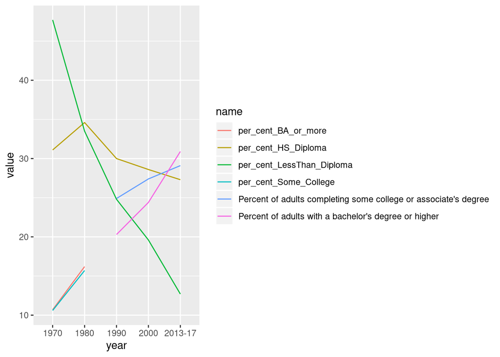

```r
percents<-ggplot(percents_df, aes(x=year, y=value, group=name, color=name)) + scale_y_continuous(labels = scales::number_format(accuracy = 1)) +
  geom_line()

print(percents)
```

Lets make a data set from unemployment and focus on the US as a whole dataset.

```r
USA_county <- clean_unemp[clean_unemp$county == 'United States',]
USA_county <- USA_county[3:8]
```

```r
drug_deaths <- read_excel("drug_induced_deaths.xlsx")
```

We’re going to sum up all the data so that we can be comparing the data for United States yearly with the unemployment data. We can also use this to compare state to state.

```r
drug_deaths_1999 <- drug_deaths[drug_deaths$Year == '1999',]
```

This allows us to focus on a single year and that allows us to compare to our Unemployment Data from the previous section.

```r
drug_deaths_1999_sum <- apply(drug_deaths_1999[,3], 2, sum)
print(drug_deaths_1999_sum)
```

```
## Deaths
##  19128
```

This summation shows that it is working, but it would be labor intensive to do this individually per area. Let’s create each individual years data.

We need to create a smaller table that has just the data we want to access attached to it, for that we will simply select the data we want (deaths, year, and population), and sum them together.

```r
USA_dd <- select(drug_deaths, 2:4)
USA_dd <- USA_dd %>% group_by(Year) %>% summarise_each(funs(sum))
colnames(USA_dd)[colnames(USA_dd) == "Year"] <- "year"
```

This is exactly what we want, but we need something else that will give us an idea if the deaths are significant to the population. We will create a new column on the USA_dd list.

```r
USA_dd$percent <- USA_dd$Deaths/USA_dd$Population
```

With a percentage column created, we can print out that it is working to make sure that it is in the “Shape” that we want so we can further distill the information.

```r
print(USA_dd)
```

```
## # A tibble: 17 x 4
##     year Deaths Population   percent
##    <dbl>  <dbl>      <dbl>     <dbl>
##  1  1999  19128  279040168 0.0000685
##  2  2000  19720  281421906 0.0000701
##  3  2001  21705  284968955 0.0000762
##  4  2002  26040  287625193 0.0000905
##  5  2003  28723  290107933 0.0000990
##  6  2004  30711  292805298 0.000105
##  7  2005  33541  295516599 0.000113
##  8  2006  38396  298379912 0.000129
##  9  2007  38371  301231207 0.000127
## 10  2008  38649  304093966 0.000127
## 11  2009  39147  306771529 0.000128
## 12  2010  40393  308745538 0.000131
## 13  2011  43544  311591917 0.000140
## 14  2012  43819  313914040 0.000140
## 15  2013  46471  316128839 0.000147
## 16  2014  49714  318857056 0.000156
## 17  2015  55403  321418820 0.000172
```

```r
print(USA_county)
```

```
## # A tibble: 11 x 6
##    county        civilian_labor  employed unemployed unemployment_rate  year
##    <chr>                  <dbl>     <dbl>      <dbl>             <dbl> <dbl>
##  1 United States      152191093 145156134    7034959              4.6   2007
##  2 United States      153761095 144860350    8900745              5.8   2008
##  3 United States      153825455 139594698   14230757              9.3   2009
##  4 United States      154270732 139408204   14862528              9.63  2010
##  5 United States      154606316 140765809   13840507              8.95  2011
##  6 United States      155119195 142600402   12518793              8.07  2012
##  7 United States      155485692 144018151   11467541              7.38  2013
##  8 United States      155957297 146338305    9618992              6.17  2014
##  9 United States      156866585 148579026    8287559              5.28  2015
## 10 United States      158708795 150981151    7727644              4.87  2016
## 11 United States      160273906 153293830    6980076              4.36  2017
```

Before we do this, we should make the “Deaths” and “percent” clear that these are based on drug overdoses or drug related deaths. We will change Deaths to drug_related_deaths_number, and percent to drug_related_deaths_percent.

```r
colnames(USA_dd)[colnames(USA_dd) == "Deaths"] <- "drug_related_deaths_number"
colnames(USA_dd)[colnames(USA_dd) == "percent"] <- "drug_related_deaths_percent"
print(USA_dd)
```

```
## # A tibble: 17 x 4
##     year drug_related_deaths_number Population drug_related_deaths_percent
##    <dbl>                      <dbl>      <dbl>                       <dbl>
##  1  1999                      19128  279040168                   0.0000685
##  2  2000                      19720  281421906                   0.0000701
##  3  2001                      21705  284968955                   0.0000762
##  4  2002                      26040  287625193                   0.0000905
##  5  2003                      28723  290107933                   0.0000990
##  6  2004                      30711  292805298                   0.000105
##  7  2005                      33541  295516599                   0.000113
##  8  2006                      38396  298379912                   0.000129
##  9  2007                      38371  301231207                   0.000127
## 10  2008                      38649  304093966                   0.000127
## 11  2009                      39147  306771529                   0.000128
## 12  2010                      40393  308745538                   0.000131
## 13  2011                      43544  311591917                   0.000140
## 14  2012                      43819  313914040                   0.000140
## 15  2013                      46471  316128839                   0.000147
## 16  2014                      49714  318857056                   0.000156
## 17  2015                      55403  321418820                   0.000172
```

Now we can combine the datasets into a new one. We’re going to be removing any data that is “NA” so that we can plot it, so we’ll be removing the NA from the merged data sets.

```r
combined_dataset <- merge(USA_dd, USA_county, by="year", all=TRUE)
combined_dataset <- na.omit(combined_dataset)
```

Now we can print that out to make sure it looks the way we want it to be.

```r
print(combined_dataset)
```

```
##    year drug_related_deaths_number Population drug_related_deaths_percent
## 9  2007                      38371  301231207                0.0001273806
## 10 2008                      38649  304093966                0.0001270956
## 11 2009                      39147  306771529                0.0001276096
## 12 2010                      40393  308745538                0.0001308294
## 13 2011                      43544  311591917                0.0001397469
## 14 2012                      43819  313914040                0.0001395892
## 15 2013                      46471  316128839                0.0001470002
## 16 2014                      49714  318857056                0.0001559131
## 17 2015                      55403  321418820                0.0001723701
##           county civilian_labor  employed unemployed unemployment_rate
## 9  United States      152191093 145156134    7034959              4.60
## 10 United States      153761095 144860350    8900745              5.80
## 11 United States      153825455 139594698   14230757              9.30
## 12 United States      154270732 139408204   14862528              9.63
## 13 United States      154606316 140765809   13840507              8.95
## 14 United States      155119195 142600402   12518793              8.07
## 15 United States      155485692 144018151   11467541              7.38
## 16 United States      155957297 146338305    9618992              6.17
## 17 United States      156866585 148579026    8287559              5.28
```

Now, with the datacombined into a single tibble that we can operate on we can do some modeling. To do so we’ll need to turn everything into continous data for graphing.

```r
as.numeric(combined_dataset$year)
```

```
## [1] 2007 2008 2009 2010 2011 2012 2013 2014 2015
```

```r
as.numeric(combined_dataset$drug_related_deaths_number)
```

```
## [1] 38371 38649 39147 40393 43544 43819 46471 49714 55403
```

```r
as.numeric(combined_dataset$Population)
```

```
## [1] 301231207 304093966 306771529 308745538 311591917 313914040 316128839
## [8] 318857056 321418820
```

```r
as.numeric(combined_dataset$drug_related_deaths_percent)
```

```
## [1] 0.0001273806 0.0001270956 0.0001276096 0.0001308294 0.0001397469
## [6] 0.0001395892 0.0001470002 0.0001559131 0.0001723701
```

```r
as.numeric(combined_dataset$civilian_labor)
```

```
## [1] 152191093 153761095 153825455 154270732 154606316 155119195 155485692
## [8] 155957297 156866585
```

```r
as.numeric(combined_dataset$employed)
```

```
## [1] 145156134 144860350 139594698 139408204 140765809 142600402 144018151
## [8] 146338305 148579026
```

```r
as.numeric(combined_dataset$unemployed)
```

```
## [1]  7034959  8900745 14230757 14862528 13840507 12518793 11467541  9618992
## [9]  8287559
```

```r
as.numeric(combined_dataset$unemployment_rate)
```

```
## [1] 4.60 5.80 9.30 9.63 8.95 8.07 7.38 6.17 5.28
```

We have now made all the datasets so that we can work on them. This is all the continuous data that we will be working on and given that we have datasets to work on, we can begin modeling.

```r
corr_set <- lm(data=combined_dataset, formula=unemployed~drug_related_deaths_number+drug_related_deaths_percent+civilian_labor)
```

We’ve created a linear regression model so that we can see if there is any correlation between the data sets we’ve choosen.

```r
summary(corr_set)
```

```
##
## Call:
## lm(formula = unemployed ~ drug_related_deaths_number + drug_related_deaths_percent +
##     civilian_labor, data = combined_dataset)
##
## Residuals:
##        9       10       11       12       13       14       15       16
##  -576529 -2095881  1314025  1731536  2541289 -1209137 -1000246 -1689860
##       17
##   984804
##
## Coefficients:
##                                        Estimate          Std. Error t value
## (Intercept)                      -11324063.0072      470649572.9961  -0.024
## drug_related_deaths_number            6319.0568           5975.6419   1.057
## drug_related_deaths_percent -2460488644993.7524  2015665213272.6379  -1.221
## civilian_labor                           0.5906              2.9582   0.200
##                             Pr(>|t|)
## (Intercept)                    0.982
## drug_related_deaths_number     0.339
## drug_related_deaths_percent    0.277
## civilian_labor                 0.850
##
## Residual standard error: 2107000 on 5 degrees of freedom
## Multiple R-squared:  0.6585, Adjusted R-squared:  0.4536
## F-statistic: 3.214 on 3 and 5 DF,  p-value: 0.1206
```

```r
prediction <-data.frame(drug_predict = predict(corr_set, combined_dataset), deaths=combined_dataset$drug_related_deaths_number)
```

We’ve created a plot variable that we can work on.

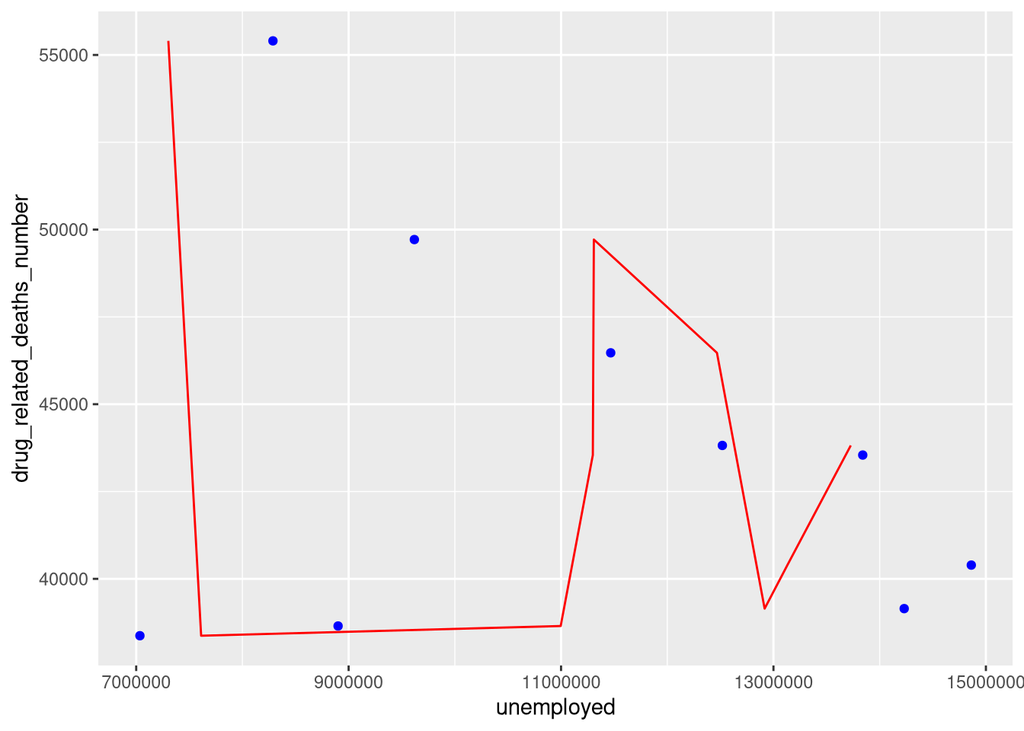

```r
ggplot(data=combined_dataset, aes(x=unemployed,y=drug_related_deaths_number)) + geom_point(color='blue') + geom_line(color='red', data = prediction, aes(x=drug_predict, y=deaths))
```